# Single Cell Comparative Network Reconstruction with scCNR

In this Notebook we use scCNR to reconstruct the same signaling network of the scMRA_Tutorial comparatively between two cell populations. Next to the wildtype populations that we analyzed in the scMRA_Tutorial we here have as well a simulated BRAF cell population. ScCNR tries to not only identify the network topology, but also identify the main differences in signaling between the wildtype and BRAF mutant population.

```python
import scmra
import pandas as pd
import numpy as np
import seaborn as sns; sns.set_theme()
import matplotlib.pyplot as plt
from IPython.display import display, HTML
import networkx as nx

#read in data
dataWT = pd.read_csv("../data/scData_wildtype.tsv", sep='\t')
dataBRAF = pd.read_csv("../data/scData_BRAFmut.tsv", sep='\t')
```

## Data Preparation

Similar to scMRA we need to calculate deviations of single cells to the population mean. Since we now consider several populations of single cells, we additionally need to assign group labels to map a cellID to its population.

```python
#add a SC-ID
dataWT.index = ["CTR."+str(i) for i in range(dataWT.shape[0])]
dataBRAF.index = ["BRAFmut."+str(i) for i in range(dataBRAF.shape[0])]

#calculate input: deviatipon of protein from cell population mean
controlPopulation = dataWT
additionalPopulations = [dataBRAF]
dataScaled, groupAnnot = scmra.prepare_data(controlPopulation, dataList = additionalPopulations, groupList = ["BRAFmut"])

#get active protein deviations (frmo those we infer interaction strengths)
rglob = dataScaled.loc[[n for n in list(dataScaled.index) if ("Active" in n)]]
rglob.index = [i.replace("Active", "") for i in rglob.index]

#get total protein deviations: 'natural perturbations'
rtot = dataScaled.loc[[n for n in list(dataScaled.index) if ("Tot" in n)]]
rtot.index = [i.replace("Tot", "") for i in rtot.index]

display(rglob.head)
```

```
<bound method NDFrame.head of            CTR.0     CTR.1     CTR.2     CTR.3     CTR.4     CTR.5     CTR.6  \
Sos    -0.051155  0.085232  0.008321  0.073530  0.037336  0.077462  0.092302
Ras    -0.076395  0.054095 -0.007728  0.025145  0.028869  0.058157  0.088900
Raf1   -0.103680  0.069777  0.053183  0.041268  0.066881  0.064294  0.005852
Mek    -0.033101 -0.152314 -0.050093 -0.128995  0.069491 -0.148370  0.166537
Erk    -0.106257 -0.177075  0.030958 -0.113891  0.051923 -0.161771  0.092711
P90Rsk -0.129504 -0.117604 -0.007665 -0.074405 -0.126830 -0.019424  0.120107
PI3K    0.142959  0.021876 -0.143707  0.023346  0.029151  0.198616  0.008005
Akt     0.116549 -0.098978 -0.143954 -0.084988  0.046098  0.104219  0.110371
C3G     0.007717 -0.082415 -0.006071 -0.138128  0.056060 -0.083842 -0.024886
Rap1   -0.005878 -0.069144  0.016994 -0.137141  0.027891 -0.114642  0.005731
bRaf    0.072555 -0.084724 -0.030218 -0.107014  0.048830 -0.116599  0.097450

           CTR.7     CTR.8     CTR.9  ...  BRAFmut.240  BRAFmut.241  \
Sos    -0.008603 -0.222532  0.126810  ...    -0.146622    -0.093920
Ras     0.004750 -0.215548  0.117134  ...    -0.129316    -0.127258
Raf1    0.066933 -0.259652  0.135834  ...    -0.123249    -0.081300
Mek     0.058568  0.107128 -0.142194  ...     0.111068    -0.166231
Erk     0.024951  0.221935 -0.127559  ...     0.102615     0.071023
P90Rsk  0.015984  0.237644 -0.188018  ...     0.238576    -0.028478
PI3K    0.087303 -0.074450 -0.020944  ...     0.052805     0.006293
Akt    -0.176313  0.044074 -0.082037  ...     0.036224    -0.175243
C3G     0.005292  0.115988  0.113998  ...     0.052111     0.107812
Rap1    0.009414  0.123415  0.086880  ...     0.055672     0.117495
bRaf    0.006757  0.086650  0.085719  ...     0.031120     0.183854

        BRAFmut.242  BRAFmut.243  BRAFmut.244  BRAFmut.245  BRAFmut.246  \
Sos        0.041602     0.083655     0.090291    -0.179314     0.160474
Ras        0.041264     0.118002     0.074339    -0.171745     0.168231
Raf1       0.017540     0.185428     0.098197    -0.200488     0.163796
Mek       -0.066659    -0.113333    -0.065334     0.011382     0.044878
Erk        0.223207    -0.092159    -0.069101    -0.063405    -0.034418
P90Rsk     0.026048    -0.060250    -0.011676     0.124937     0.005208
PI3K       0.030364    -0.048787    -0.154532    -0.080240     0.048716
Akt        0.104959    -0.075421    -0.116958     0.152433    -0.011654
C3G        0.138902     0.092160    -0.031306    -0.015758    -0.005661
Rap1       0.164348     0.098692    -0.030684     0.013867    -0.006914
bRaf      -0.019847     0.222383    -0.149625    -0.095272     0.202139

        BRAFmut.247  BRAFmut.248  BRAFmut.249
Sos        0.366688     0.029405    -0.023816
Ras        0.407325     0.011223    -0.040518
Raf1       0.496338    -0.056441    -0.009805
Mek       -0.043485    -0.000050     0.031329
Erk       -0.059881    -0.025874     0.281526
P90Rsk    -0.180146     0.017860     0.090534
PI3K      -0.188240    -0.041037    -0.089324
Akt        0.003887     0.010586    -0.002628
C3G        0.099245    -0.083501    -0.032298
Rap1       0.110646    -0.056336    -0.041837
bRaf       0.052489    -0.135774     0.252340

[11 rows x 500 columns]>
```

## Define Network Sparcity

scCNR penalizes the number of non-equal edges in the network(additional to the number of edges in the network). Similar to the estimation of a suitable η-parameter, the θ-penalty on non-equal edges can also be estimated (see scMRA_Tutorial). Here we continue with parameters that we estimated for the method evaluation in the paper.

## Reconstruct the network

The result of the scCNR ananlysis return not only one weighted adjacency matrix of the inferred network, but one matrix for each cell population. Depending on the θ-penalty we force edges to be similar between networks, and would ideally retain 'rloc' matrices, that are fairly similar and differ in the main interactions that explain hte main signaling differences between the populations. Here we display the differences between the wildtype and BRAFmut population and see that most differences are detected downstream of BRAF.

```python
%%capture

#make MRA simulation
eta = 0.02
theta = 0.1
scd = scmra.ScData(rglob=rglob, rtot = rtot, group_annot= groupAnnot)
p = scmra.ScCnrProblem(scd, eta=eta, theta=theta)
p.cpx.solve()
result = scmra.ScCnrResult(p)
```

|  | Sos | Ras | Raf1 | Mek | Erk | P90Rsk | PI3K | Akt | C3G | Rap1 | bRaf |
| --- | --- | --- | --- | --- | --- | --- | --- | --- | --- | --- | --- |
| Sos | 0.0 | 0.0 | 0.0 | 0.000000 | 0.000000 | 0.0 | 0.0 | 0.0 | 0.0 | 0.0 | 0.000000 |
| Ras | 0.0 | 0.0 | 0.0 | 0.000000 | 0.000000 | 0.0 | 0.0 | 0.0 | 0.0 | 0.0 | 0.000000 |
| Raf1 | 0.0 | 0.0 | 0.0 | 0.000000 | 0.000000 | 0.0 | 0.0 | 0.0 | 0.0 | 0.0 | 0.000000 |
| Mek | 0.0 | 0.0 | 0.0 | 0.000000 | 0.000000 | 0.0 | 0.0 | 0.0 | 0.0 | 0.0 | 0.791585 |
| Erk | 0.0 | 0.0 | 0.0 | 0.965511 | 0.000000 | 0.0 | 0.0 | 0.0 | 0.0 | 0.0 | 0.000000 |
| P90Rsk | 0.0 | 0.0 | 0.0 | 0.000000 | 0.701235 | 0.0 | 0.0 | 0.0 | 0.0 | 0.0 | 0.000000 |
| PI3K | 0.0 | 0.0 | 0.0 | 0.000000 | 0.000000 | 0.0 | 0.0 | 0.0 | 0.0 | 0.0 | 0.000000 |
| Akt | 0.0 | 0.0 | 0.0 | 0.000000 | 0.000000 | 0.0 | 0.0 | 0.0 | 0.0 | 0.0 | 0.000000 |
| C3G | 0.0 | 0.0 | 0.0 | 0.000000 | 0.000000 | 0.0 | 0.0 | 0.0 | 0.0 | 0.0 | 0.000000 |
| Rap1 | 0.0 | 0.0 | 0.0 | 0.000000 | 0.000000 | 0.0 | 0.0 | 0.0 | 0.0 | 0.0 | 0.000000 |
| bRaf | 0.0 | 0.0 | 0.0 | 0.000000 | 0.000000 | 0.0 | 0.0 | 0.0 | 0.0 | 0.0 | 0.000000 |

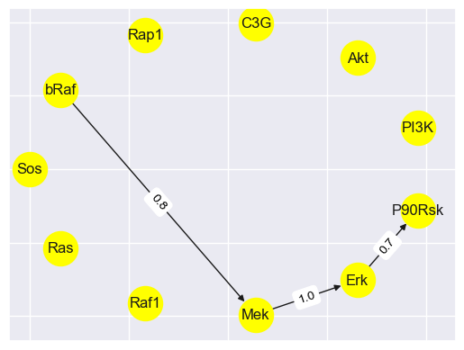

```python
#display difference between both adjacency matrices
display(result.rloc["Ctr"] - result.rloc["BRAFmut"])
differenceRloc = result.rloc["Ctr"] - result.rloc["BRAFmut"]

#diagonal rloc entries are per definition -1, replace those with 0 to plot network
A = differenceRloc.transpose()
A[A == -1] = 0
G = nx.from_pandas_adjacency(A, create_using=nx.DiGraph)

pos=nx.shell_layout(G)
nx.draw_networkx(G, with_labels=True, node_size = 750, pos = pos, node_color = "yellow")
#create edge labels
edgeLabels = {}
edgeColor = {}
for row_label, row_data in A.iterrows():
    for col_label, value in row_data.items():
        key = (col_label, row_label)
        if(np.abs(value) > 0):
            edgeLabels[key] = round(value,1)

nx.draw_networkx_edge_labels(
    G, pos,
    edge_labels=edgeLabels,
    font_color="black"
)
plt.show()
```